# Modelos de Equações Estruturais Longitudinais

## IM Longitudinal

### Invariância estrita

```r
syntax.strict <- measEq.syntax(configural.model = syntax.config, data = DF_mood,
                               ID.fac = "std.lv", longFacNames = longFacNames,
                               long.equal  = c("loadings", "intercepts", "residuals"))
summary(syntax.strict ) # summarize model features
mod.strict <- as.character(syntax.strict ) # save as text
strict.fit <- cfa(mod.strict, data = DF_mood, meanstructure=T, meanstructure=T , std.lv = T, missing = "fiml", estimator="MLR")
summary(strict.fit, standardized=TRUE, fit.measures=TRUE, rsquare = TRUE)

summary(compareFit(scalar.fit, strict.fit))
```

## Exercício prático - Parte 1 (ver “LongSEM_ex.html”)

## Modelos de crescimento latente (LGC)

## LGC - Introdução

Os LGC focam-se primariamente na análise das **trajetórias de mudança** que caracterizam um grupo de pessoas numa determinada variável

Estas trajetórias são caracterizadas de acordo com 2 parâmetros:  
(1) Média de crescimento; (2) Variação (variância) inter-individual

*Sendo possível caracterizar os padrões médios de mudança de um determinado grupo de pessoas, é também útil reconhecer que na maioria das situações diferentes pessoas apresentam padrões de mudança distintos*

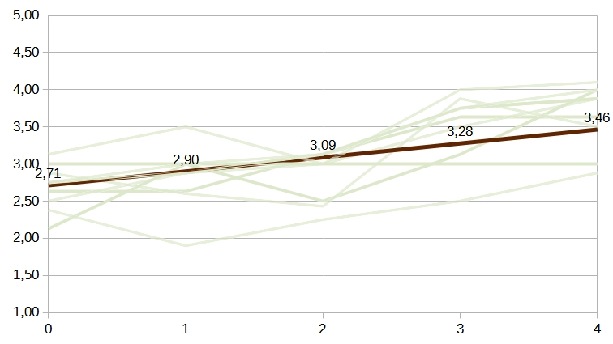

## LGC - Introdução

Os modelos LGC respondem a três questões essenciais (Bollen & Curran, 2006):

- Como se caracteriza a trajetória média de mudança de um grupo de sujeitos numa variável?  
  *Será que existem mudanças significativas ao longo do tempo e como se podem caracterizar essas mudanças?*
- A trajetória média estimada é suficiente para explicar as mudanças nos diferentes padrões individuais de trajetórias?  
  *Será que existe variabilidade intra-individual nos níveis iniciais (i.e., intercept) e taxa mudança (i.e., slope)?*
- Se existe variabilidade nas trajetórias individuais, será que podemos recorrer a outras variáveis para explicar essa variabilidade?  
  *Que variáveis são necessárias para explicar as diferenças individuais (i.e., variância) nos momentos iniciais e trajetórias de mudança?*

## Modelos de crescimento latente

Estes modelos procuram explicar uma variável em função do tempo, descrevendo:  
- Nível inicial e trajetória de mudança médias dos indivíduos  
- Diferenças inter-individuais nestes parâmetros

Oferecem uma forma flexível de testar o valor preditivo de outras variáveis face às trajetórias

Os modelos LGC podem assumir crescimento linear ou não linear

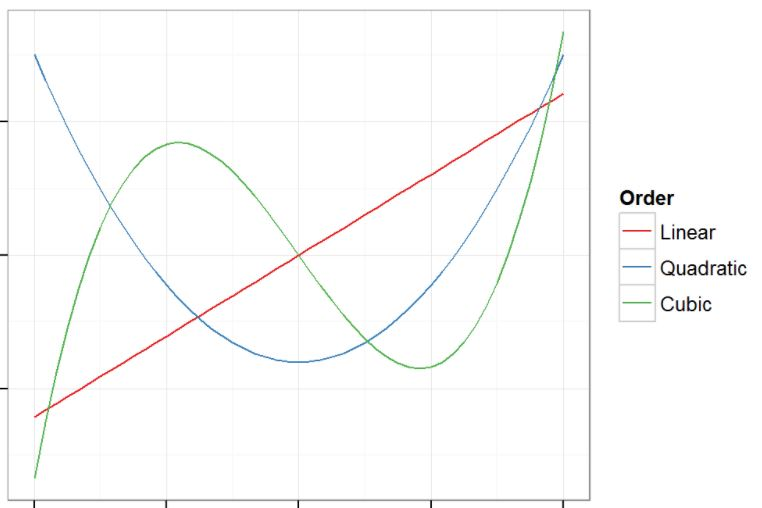

## Modelo de crescimento latente

Definido pelas seguintes equação multinível genéricas:

**Nível 1 (mudança intraindividual associada ao tempo - within-subject):**  
\[{y_{ti}} = \beta_{0i} + \beta_{1i}x_{ti} + r_{ti}\] LEGENDA:  
- *i* = indivíduos & *t* = ocasião de medida;  
- \({Y_{ti}}\) = score do indivíduo *i* na variável *y* no tempo *t*;  
- \(x_{ti}\) = variável que define a unidade de tempo;  
- \(\beta_{0i}\) = o intercept do indivíduo *i*, isto é, o score de *y* no primeiro momento de avaliação, quando *t* é igual a zero;  
- \(\beta_{1i}\) = a slope do indivíduo *i*, definida pela variável *t*. Corresponde à trajetória de crescimento de cada um dos indivíduos ao longo do tempo;  
- \(r_{ti}\) = resíduo associado ao score do indivíduo *i* na ocasião *t* - discrepância entre a trajetória individual estimada e o valor observado;

## Modelo de crescimento latente

**Nível 1 (mudança intraindividual associada ao tempo - within-subject):**  
\[{y_{ti}} = \beta_{0i} + \beta_{1i}x_{ti} + r_{ti}\]

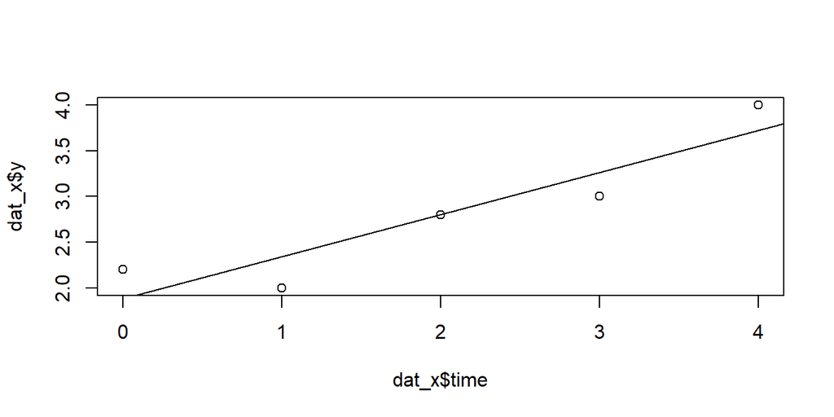

## Modelo de crescimento latente

O tempo pode não explicar todas as diferenças ao nível…  
- do ponto de partida (\(\beta_{0i}\))  
- da trajetória de mudança (\(\beta_{1i}\))

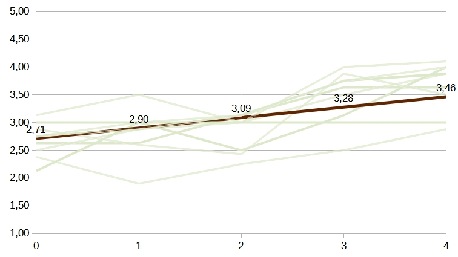

Para melhor representar os nossos dados, torna-se necessário integrar no modelo a variabilidade individual tanto ao nível de \(\beta_{0i}\) como de \(\beta_{1i}\)

## Modelo de crescimento latente

### Nível 2 (variação interindividuais, between-subjec): INTERCEPT

\[\beta_{0i} = \gamma_{00} + u_{0i}\]

LEGENDA:  
- *i* = indivíduos;  
- \(\beta_{0i}\) = intercept do indivíduo *i*, valor esperado de *Y* quando *t*=0;  
- \(\gamma_{00}\) = média de todos os intercepts, ou intercept da equação de nível 2 predizendo \(\beta_{0i}\), o intercept da equação de nível 1;  
- \(u_{0i}\) = desvio de cada indivíduo *i* face ao intercept médio ou variância da slope;

NOTA: a esta equação podem ser acrescentados parâmetros (eg., \(\gamma_{10}\), \(\gamma_{20}\)…) que potencialmente expliquem \(\beta_{0i}\)

## Modelo de crescimento latente

### Nível 2 (variação interindividuais, between-subjec): INTERCEPT

\[\beta_{0i} = \gamma_{00} + u_{0i}\]

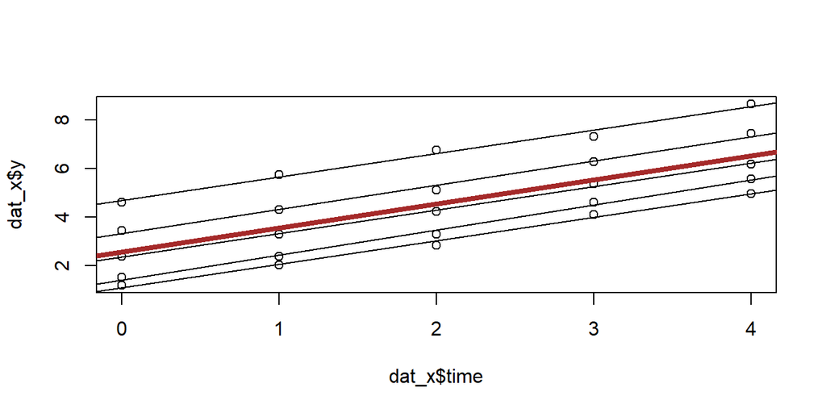

## Modelo de crescimento latente

### Nível 2 (variação interindividuais, between-subjec): SLOPE

\[\beta_{1i} = \gamma_{10} + u_{1i}\] LEGENDA:  
- *i* = indivíduos;  
- \(\beta_{1i}\) = a slope do indivíduo *i*, definida pela variável *t*. Corresponde à trajetória de crescimento de cada um dos indivíduos ao longo do tempo;  
- \(\gamma_{10}\) = média de todas as slope, ou intercept da equação de nível 2 predizendo \(\beta_{1i}\), a slope da equação de nível 1;  
- \(u_{1i}\) = desvio de cada indivíduo *i* face à slope média ou variância da slope;

NOTA: a esta equação podem ser acrescentados parâmetros (eg., \(\gamma_{10}\), \(\gamma_{20}\)…) que potencialmente expliquem \(\beta_{1i}\)

## Modelo de crescimento latente

### Nível 2 (variação interindividuais, between-subjec): SLOPE

\[\beta_{1i} = \gamma_{10} + u_{1i}\]

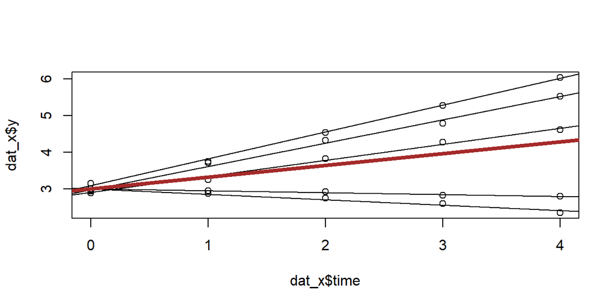

## Modelo de crescimento latente

### Nível 1 e 2 (variação intra e interindividuais): INTERCEPT & SLOPE

\[{y_{ti}} = (\gamma_{00} + u_{0i}) + (\gamma_{10} + u_{1i})x_{ti} + r_{ti}\] \[{y_{ti}} = \gamma_{00} + \gamma_{10}x_{ti} + u_{0i} + u_{1i}x_{ti} + r_{ti}\] O modelo completo incluí assim 3 componentes de erro:  
- \(r_{ti}\) que corresponde a diferenças intraindividuais (**erro na equação de nível 1**)  
- \(u_{0i}\) e \(u_{1i}\) que corresponde a diferenças interindividuais ao nível do intercept e slope (**erros nas equações de nível 2**)

## Modelos de crescimento latente

\[{y_{ti}} = \gamma_{00} + \gamma_{10}x_{ti} + u_{0i} + u_{1i}x_{ti} + r_{ti}\]

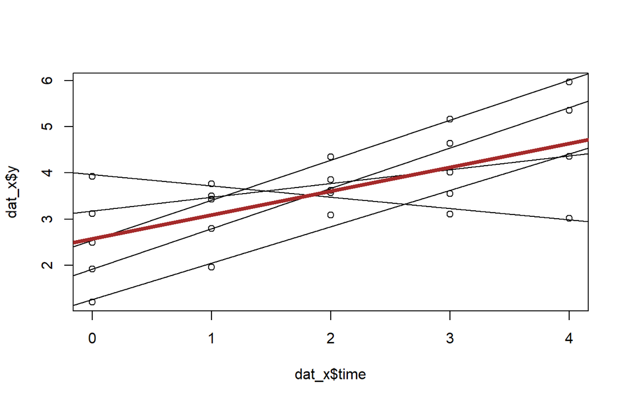

## Modelo de crescimento latente

A equação da regressão multinível…  
\[{y_{ti}} = \gamma_{00} + \gamma_{10}x_{ti} + u_{0i} + u_{1i}x_{ti} + r_{ti}\] …é reproduzida no diagrama SEM para o modelo LGC:

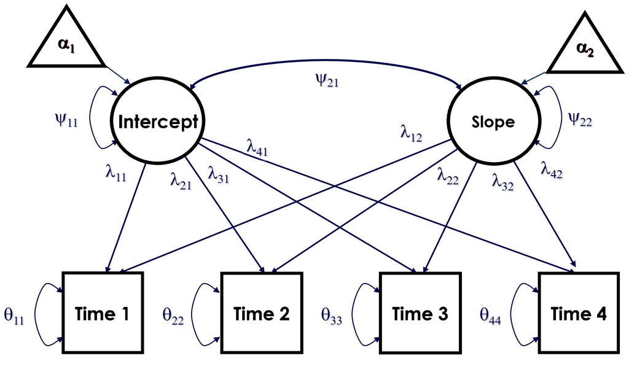

\[{y_{ti}} = \alpha_{1} + \alpha_{2}\lambda_{t2} + \zeta_{1i} + \zeta_{2i}\lambda_{ti} + \varepsilon_{ti}\]

## Modelo de crescimento latente

A especificação do modelo fica completa com a codificação de tempo (*t* na equação anterior)  
- Este codificação irá definir a forma da slope: linear, quadrática, cúbica…

Codificação **linear** de *t* para 4 ocasiões

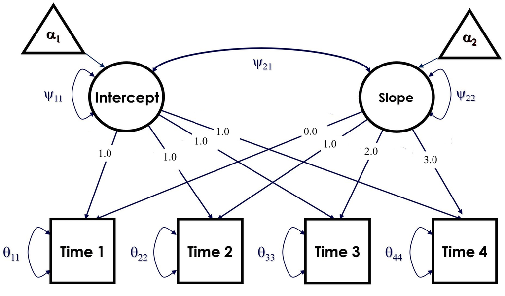

- Intercept fixado a 1 nas diferentes ocasiões de medida
- Slope fixadas a 0, 1, 2 e 3 respetivamente à primeira, segunda, terceira e quarta ocasião de medida

## Modelo de crescimento latente

**O intercept (\(\beta_{0i}\))**:  
- Loadings fixados a 1 nas quatro ocasiões de medida  
- Constante que captura o valor médio de \({y_{ti}}\) quando a variável preditora, neste caso **tempo**, assume o valor de zero.

**A slope (\(\beta_{1i}\))**:  
- Loadings são fixados a 0, 1, 2 e 3, respetivamente no tempo 1, 2, 3 e 4  
- Esta codificação reflete a linearidade do crescimento latente ao longo dos 4 momentos

## Modelo de crescimento latente - Sumário

Os modelos LGC caracterizam as mudanças individuais de acordo com:  
- médias do intercept e slope  
- variação inter individual

Como estes **parâmetros são tratado como variáveis latentes**, podem ser modelados de forma muito flexível

*De seguida, apresentamos alguns exemplos de como esta modelação pode ser executada com recurso ao R e ao pacote lavaan.*

## Especificação, estimação e avaliação de Modelos de Crescimento Latente (LGC) no R

Nos exemplos que se seguem recorremos mais uma vez à base de dados apresentada por Todd Little (2013) no seu livro *Longitudinal structural equation modeling*.

Usamos o código seguinte para importar esta base de dados:

```r
DF_LGM <- read.csv("G:\\My Drive\\FPCEUP\\AtividadeDocente\\Longitudinal_SEM\\LongSEM_Data\\lgm.csv")
```

- Algumas características desta base de dados

```r
names(DF_LGM)
class(DF_LGM)
str(DF_LGM)
```

## Estatística descritiva

```r
library(psych) # se necessário: install.packages("psych")
psych::describe(DF_LGM[ ,1:8])
```

```
##           vars    n mean   sd median trimmed  mad  min  max range  skew
## PosAFF_T1    1 1684 3.59 0.90   3.68    3.64 0.99 1.00 5.00  4.00 -0.46
## PosAFF_T2    2 1684 3.66 0.81   3.71    3.71 0.86 1.04 5.04  4.00 -0.50
## PosAFF_T3    3 1684 3.69 0.87   3.81    3.74 0.93 1.11 5.11  4.00 -0.51
## PosAFF_T4    4 1684 3.69 0.83   3.77    3.74 0.89 1.08 5.00  3.92 -0.58
## NegAFF_T1    5 1684 2.08 0.79   1.95    2.01 0.76 1.00 4.87  3.87  0.81
## NegAFF_T2    6 1684 2.00 0.72   1.89    1.93 0.73 1.00 5.00  4.00  0.80
## NegAFF_T3    7 1684 1.89 0.65   1.76    1.83 0.64 1.00 4.80  3.80  0.99
## NegAFF_T4    8 1684 1.78 0.63   1.65    1.71 0.59 1.00 5.00  4.00  1.23
##           kurtosis   se
## PosAFF_T1    -0.45 0.02
## PosAFF_T2    -0.17 0.02
## PosAFF_T3    -0.28 0.02
## PosAFF_T4    -0.20 0.02
## NegAFF_T1     0.27 0.02
## NegAFF_T2     0.39 0.02
## NegAFF_T3     1.19 0.02
## NegAFF_T4     2.01 0.02
```

## Estatística descritiva

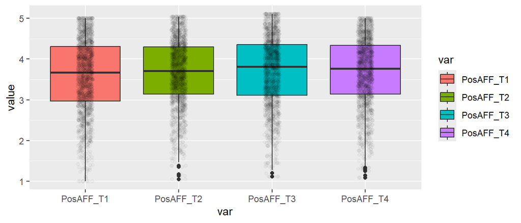

```r
#Visualização de dados
library(ggplot2) # se necessário: install.packages("ggplot2")

DF_pos <- data.frame(var=c(rep("PosAFF_T1", nrow(DF_LGM)), rep("PosAFF_T2", nrow(DF_LGM)),
                           rep("PosAFF_T3", nrow(DF_LGM)), rep("PosAFF_T4", nrow(DF_LGM))),
                     value = c(DF_LGM$PosAFF_T1, DF_LGM$PosAFF_T2, DF_LGM$PosAFF_T3, DF_LGM$PosAFF_T4))
ggplot(DF_pos, aes(x=var,y=value, fill=var)) +
  geom_boxplot() +
  geom_jitter(width=0.08, alpha=0.03)
```

## Estatística descritiva

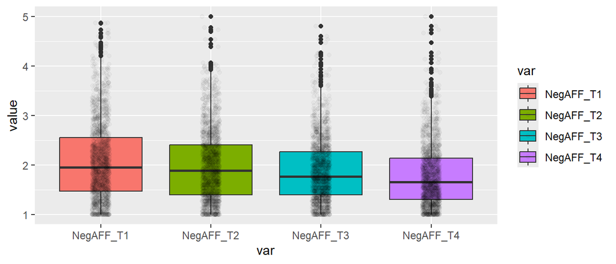

```r
DF_neg <- data.frame(var=c(rep("NegAFF_T1", nrow(DF_LGM)), rep("NegAFF_T2", nrow(DF_LGM)),
                           rep("NegAFF_T3", nrow(DF_LGM)), rep("NegAFF_T4", nrow(DF_LGM))),
                     value = c(DF_LGM$NegAFF_T1, DF_LGM$NegAFF_T2, DF_LGM$NegAFF_T3, DF_LGM$NegAFF_T4))

ggplot(DF_neg, aes(x=var,y=value, fill=var)) +
  geom_boxplot() +
  geom_jitter(width=0.08, alpha=0.03)
```

## As funções **growth()** e **sem()** (OPCIONAL)

O lavaan disponibiliza a função **growth()** para estimação de modelos de crescimento latente (LGC)  
- Esta função deixará de fazer parte do pacote em breve  
- As funções **sem()** e **growth()** são muito semelhantes  
- Ao contrario da função **sem()**, na função **growth()** assume automaticamente *meanstructure=TRUE*, fixa a zero os intercepts observados e estima livremente as médias da variáveis latentes.

A especificação e estimação de um modelo LGC com quatro ocasiões de medida usando a função **growth()** é feita da seguinte forma:

```r
modelo.8 <- "
## média inicial e trajetória linear de crescimento
intercept =~ 1*NegAFF_T1 + 1*NegAFF_T2 + 1*NegAFF_T3 + 1*NegAFF_T4
slope =~ 0*NegAFF_T1 + 1*NegAFF_T2 + 2*NegAFF_T3 + 3*NegAFF_T4
"
```

## As funções **growth()** e **sem()** (OPCIONAL)

Intercept definido fixando os seus loadings a 1 nos quatro momentos de avaliação

Slope é definida fixando a 0, 1, 2 e 3

A estimação do modelo é feita da seguinte forma:

```r
fit.8 <- growth(modelo.8, data=DF_LGM)
```

```r
summary(fit.8, standardized=T, fit.measures=T)
```

## As funções **growth()** e **sem()** (OPCIONAL)

O mesmo modelo é estimado com a função **sem()**:

```r
modelo.8.1 <- "
intercept =~ 1*NegAFF_T1 + 1*NegAFF_T2 + 1*NegAFF_T3 + 1*NegAFF_T4
slope =~ 0*NegAFF_T1 + 1*NegAFF_T2 + 2*NegAFF_T3 + 3*NegAFF_T4

## fixar os intercepts das variáveis observadas a zero e
## libertar as médias latentes (intecept e crescimento médio)
intercept ~ 1
slope ~ 1
NegAFF_T1 ~ 0*1
NegAFF_T2 ~ 0*1
NegAFF_T3 ~ 0*1
NegAFF_T4 ~ 0*1
"
```

*Explicitar a estimação livre das médias latentes e fixar os intercept observados a 0*

```r
fit.8.1 <- sem(modelo.8.1, data=DF_LGM)
```

```r
summary(fit.8.1, standardized=T, fit.measures=T)
```

## As funções **growth()** e **sem()** (OPCIONAL)

Os dois modelos estimados pelas funções **growth()** e **sem()** são idênticos

```r
summary(compareFit(fit.8, fit.8.1, nested=FALSE))
```

```
## ####################### Model Fit Indices ###########################
##           chisq df pvalue rmsea   cfi   tli  srmr        aic        bic
## fit.8   14.169†  5   .015 .033† .990† .988† .026† 13297.758  13346.618
## fit.8.1 14.169†  5   .015 .033† .990† .988† .026  13297.758† 13346.618†
```

Tal como recomendado, iremos usar a função **sem()** nos exemplos que se seguem

## Step 1: Modelo não condicionado

O teste de um modelo de LGC frequentemente inicia-se com a avaliação de um modelo não condicionado  
- Este modelo não impõe qualquer trajetória de crescimento sendo usado como modelo de base

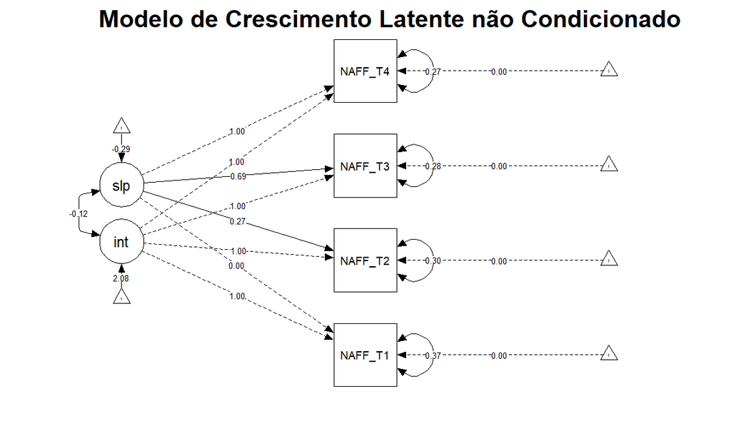

## Step 1: Modelo não condicionado

Para especificar este modelo, apenas fixar dois dos quatro loadings da slope, libertando os restantes

```r
modelo.9 <- "
## média inicial e trajetória linear de crescimento
intercept =~ 1*NegAFF_T1 + 1*NegAFF_T2 + 1*NegAFF_T3 + 1*NegAFF_T4
slope =~ 0*NegAFF_T1 + NegAFF_T2 + NegAFF_T3 + 1*NegAFF_T4

## intercepts e médias
intercept ~ 1
slope ~ 1
NegAFF_T1 ~ 0*1
NegAFF_T2 ~ 0*1
NegAFF_T3 ~ 0*1
NegAFF_T4 ~ 0*1
"
fit.9 <- sem(modelo.9, data=DF_LGM, meanstructure=TRUE)
```

```r
#sumário do modelo
summary(fit.9, standardized=TRUE, fit.measures=TRUE, rsquare=TRUE)
```

## Step 1: Modelo não condicionado

Este modelo não condicionado permite explorar a forma da trajetória de crescimento

*Se analisarmos os loadings (não estandardizados) da slope nos diferentes momentos, podemos inferir uma trajetória relativamente linear: 0 em t1, .27 em t2, .70 em t3 e 1 em t4.*

Podemos confirmar a linearidade da trajetória, testando o ajustamento do **modelo condicionado** aos dados

## STEP 2: Modelo condicionado

O modelo condicionado impõem uma slope linear, fixando todos os seus loadings a 0, 1, 2 e 3

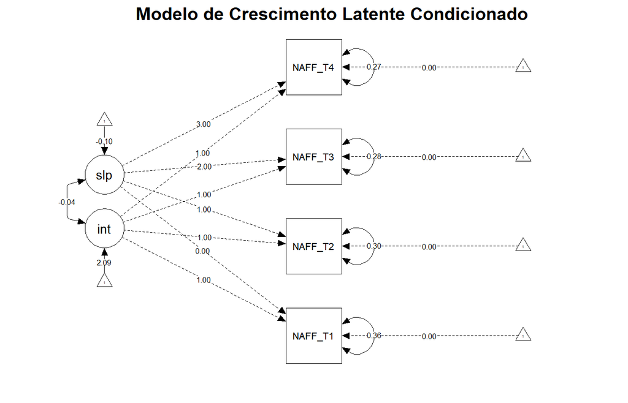

## STEP 2: Modelo condicionado

```r
modelo.10 <- "
## média inicial e trajetória linear de crescimento
intercept =~ 1*NegAFF_T1 + 1*NegAFF_T2 + 1*NegAFF_T3 + 1*NegAFF_T4
slope =~ 0*NegAFF_T1 + 1*NegAFF_T2 + 2*NegAFF_T3 + 3*NegAFF_T4

## intercepts e médias
intercept ~ 1
slope ~ 1
NegAFF_T1 ~ 0*1
NegAFF_T2 ~ 0*1
NegAFF_T3 ~ 0*1
NegAFF_T4 ~ 0*1
"
fit.10 <- sem(modelo.10, data=DF_LGM, meanstructure=TRUE)
```

## STEP 2: Modelo condicionado

```r
#sumário do modelo
summary(fit.10, standardized=TRUE, fit.measures=TRUE, rsquare=TRUE)
```

Este modelo pode ser retido uma vez que não difere significativamente do modelo não condicionado, sendo mais mais parcimonioso

```r
anova(fit.9, fit.10)
```

```
##
## Chi-Squared Difference Test
##
##        Df   AIC   BIC  Chisq Chisq diff     RMSEA Df diff Pr(>Chisq)
## fit.9   3 13300 13359 12.050
## fit.10  5 13298 13347 14.169     2.1187 0.0059375       2     0.3467
```

## Interpretação dos resultados

Pelo sumário do modelo anterior verificamos que:

- Tanto o intercept (*b* = 2.09) como a slope (*b* = -.10) apresentam valores significativos
  - *Nível médio de afeto negativo de 2.09 em T0 com decréscimo linear a uma taxa média de -.10 (por ano)*
- As variâncias do intercept (*b* = .27) e slope (*b* = .01) também são ambas significativas
  - Existência de variabilidade entre indivíduos, tanto no que toca ao níveis iniciais de afeto negativo como às trajetórias de mudança

## Interpretação dos resultados

Correlação significativa entre o intercept e a slope b (*r* = -.71).  
- Com **slope positiva** uma correlação negativa sugere que sujeitos com níveis iniciais mais elevados de afeto apresentam um crescimento menor ao longo do tempo.  
- Com **slope negativa** (há um decréscimo ao longo do tempo), uma **correlação negativa** com o intercept indica que:  
- Scores de pessoas com níveis *iniciais de afeto mais elevados* tendem a *decrescer mais* ao longo do tempo (slope mais negativa).  
- Scores de pessoas com níveis *iniciais de afeto mais baixo*s deverão *decrescer menos* ao longo do tempo (slope menos negativa).

Podemos também interpretar o R-square.  
- Ligeiro decréscimo da variância explicada dos indicadores pelo fator (slope) ao longo do tempo

## LGC: Constrangimentos ao modelo

É prática frequente impor constrangimentos ao modelo com o objetivo de aumentar a sua parcimónia.  
- Igualar os resíduos dos indicadores - correspondência com pressuposto da *homogeneidade das variâncias* nos modelos clássicos de regressão.

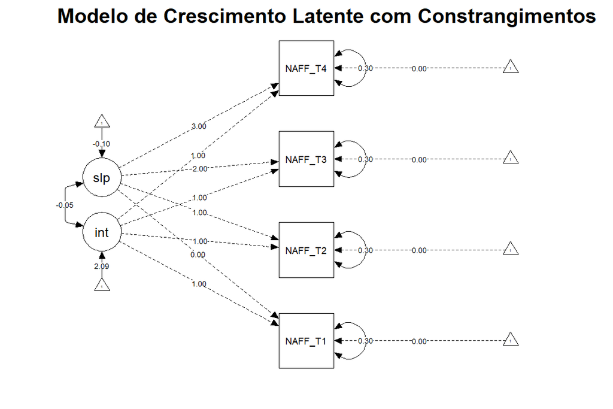

## LGC: Constrangimentos ao modelo

```r
modelo.10.1 <- "
## média inicial e trajetória linear de crescimento
intercept =~ 1*NegAFF_T1 + 1*NegAFF_T2 + 1*NegAFF_T3 + 1*NegAFF_T4
slope =~ 0*NegAFF_T1 + 1*NegAFF_T2 + 2*NegAFF_T3 + 3*NegAFF_T4

## intercepts e médias
intercept ~ 1
slope ~ 1
NegAFF_T1 ~ 0*1
NegAFF_T2 ~ 0*1
NegAFF_T3 ~ 0*1
NegAFF_T4 ~ 0*1

## Fixar as variâncias residuais ao mesmo valor
NegAFF_T1 ~~ res1*NegAFF_T1
NegAFF_T2 ~~ res1*NegAFF_T2
NegAFF_T3 ~~ res1*NegAFF_T3
NegAFF_T4 ~~ res1*NegAFF_T4
"
fit.10.1 <- sem(modelo.10.1, data=DF_LGM, meanstructure=TRUE)

#sumário do modelo
summary(fit.10.1, standardized=TRUE, fit.measures=TRUE, rsquare=TRUE)
```

## LGC: Constrangimentos ao modelo

Os resultados da função **compareFit()** indicam que os dois modelos (com e sem constrangimentos) diferem significativamente no seu ajustamento aos dados  
- O ajustamento piora com os constrangimentos

```r
summary(compareFit(fit.10, fit.10.1))
```

```
## ################### Nested Model Comparison #########################
##
## Chi-Squared Difference Test
##
##          Df   AIC   BIC  Chisq Chisq diff    RMSEA Df diff Pr(>Chisq)
## fit.10    5 13298 13347 14.169
## fit.10.1  8 13310 13343 32.671     18.502 0.055393       3  0.0003465 ***
## ---
## Signif. codes:  0 '***' 0.001 '**' 0.01 '*' 0.05 '.' 0.1 ' ' 1
##
## ####################### Model Fit Indices ###########################
##            chisq df pvalue rmsea   cfi   tli  srmr        aic        bic
## fit.10   14.169†  5   .015 .033† .990† .988† .026† 13297.758† 13346.618
## fit.10.1 32.671   8   .000 .043  .973  .980  .034  13310.260  13342.833†
##
## ################## Differences in Fit Indices #######################
##                   df rmsea    cfi    tli  srmr    aic    bic
## fit.10.1 - fit.10  3  0.01 -0.017 -0.008 0.008 12.502 -3.785
```

## LGC: Visualização (OPCIONAL)

As seguintes linhas de código são opcionais e servem para visualizar os valores individuais e médios estimados pelo modelo.

```r
DF_FIT.10.1 <- as.data.frame(cbind(1:nrow(DF_LGM), predict(fit.10.1)))
names(DF_FIT.10.1)[1] <- "ID"
DF_FIT.10.1$ID <- rep("subjets", nrow(DF_FIT.10.1))
DF_FIT.10.1.sel <- DF_FIT.10.1[sample(1:nrow(DF_FIT.10.1),100), ]

DF_coef_fit.10.1 <- as.data.frame(matrix(coef(fit.10.1)[1:2], ncol=2, byrow=TRUE))
DF_coef_fit.10.1 <- as.data.frame(c("Average Est", DF_coef_fit.10.1), col.names=names(DF_FIT.10.1))
```

## LGC: Visualização (OPCIONAL)

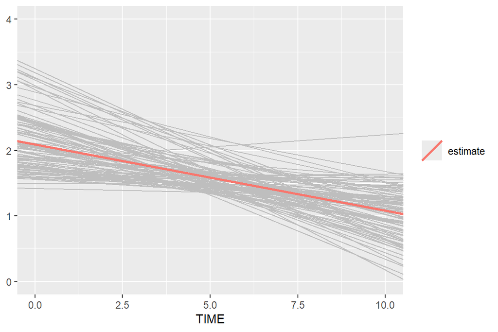

```r
ggplot() +
  scale_y_continuous(limits=c(0,4)) +
  geom_abline(data= DF_FIT.10.1.sel, aes(slope=slope, intercept=intercept), colour="grey") +
  geom_abline(data= DF_coef_fit.10.1, aes(slope=slope, intercept=intercept, colour="estimate"), size=1) +
  theme(legend.title = element_blank()) +
  scale_x_continuous("TIME", limits=c(0,10))
```

## LGC: Modelo de crescimento com covariáveis fixas no tempo

Os modelos LGC permitem incluir covariáveis para explicar a variância do intercept e da slope  
No modelo seguinte estimamos o efeito de 3 variáveis dicotómicas:  
- “gender_male”;  
- “Black”;  
- “Hispanic”;

## LGC: Modelo de crescimento com covariáveis fixas no tempo

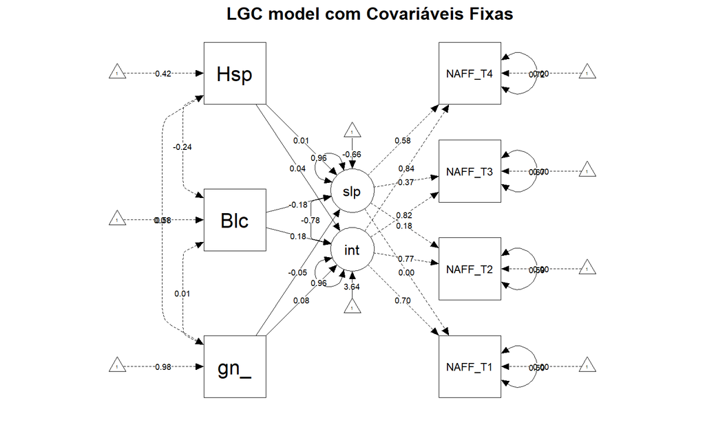

## LGC: Modelo de crescimento com covariáveis fixas no tempo

```r
modelo.11 <- "
## média inicial e trajetória linear de crescimento
intercept =~ 1*NegAFF_T1 + 1*NegAFF_T2 + 1*NegAFF_T3 + 1*NegAFF_T4
slope =~ 0*NegAFF_T1 + 1*NegAFF_T2 + 2*NegAFF_T3 + 3*NegAFF_T4

## intercepts e médias
intercept ~ 1; slope ~ 1
NegAFF_T1 ~ 0*1; NegAFF_T2 ~ 0*1; NegAFF_T3 ~ 0*1; NegAFF_T4 ~ 0*1

## Fixar as variâncias residuais ao mesmo valor
NegAFF_T1 ~~ res1*NegAFF_T1; NegAFF_T2 ~~ res1*NegAFF_T2;
NegAFF_T3 ~~ res1*NegAFF_T3; NegAFF_T4 ~~ res1*NegAFF_T4

# Covariáveis
intercept ~ gender_male + Black + Hispanic
slope ~ gender_male + Black + Hispanic
"
fit.11 <- sem(modelo.11, data=DF_LGM, meanstructure=TRUE)
```

## LGC: Modelo de crescimento com covariáveis fixas no tempo

```r
#sumário do modelo
summary(fit.11, fit.measures=TRUE, rsquare=TRUE)
```

## LGC: Modelo de crescimento linear multivariado

Um exemplo adicional das potencialidade analíticas dos modelos de crescimento latente consiste na possibilidade de estimar trajetórias de crescimento de diferentes variáveis

- No modelo seguintes, para além do afeto negativo, estimamos a trajetória de crescimento de outra variável, afeto positivo.

## LGC: Modelo de crescimento linear multivariado

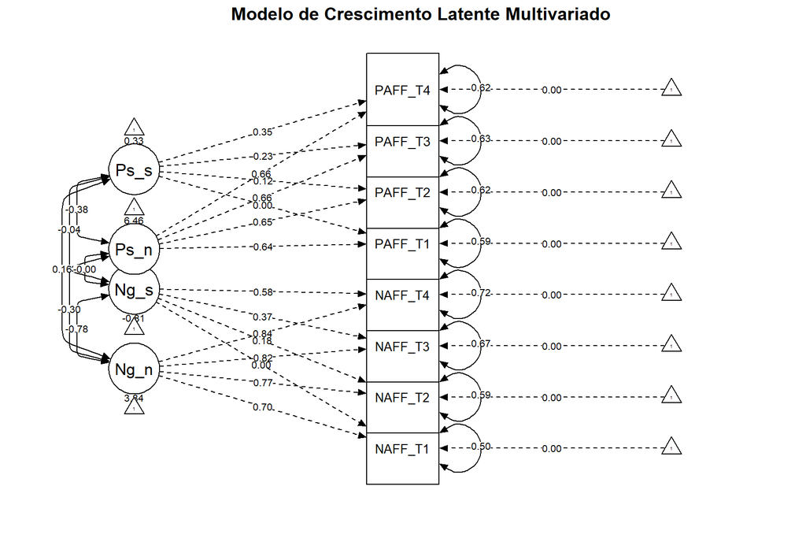

[output not shown]

[output cut: 73 more lines]

[output not shown]

## LGC: Modelo de crescimento linear multivariado

```r
modelo.12 <- "
## média inicial e trajetória linear de crescimento
Neg_intercept =~ 1*NegAFF_T1 + 1*NegAFF_T2 + 1*NegAFF_T3 + 1*NegAFF_T4
Neg_slope =~ 0*NegAFF_T1 + 1*NegAFF_T2 + 2*NegAFF_T3 + 3*NegAFF_T4
Pos_intercept =~ 1*PosAFF_T1 + 1*PosAFF_T2 + 1*PosAFF_T3 + 1*PosAFF_T4
Pos_slope =~ 0*PosAFF_T1 + 1*PosAFF_T2 + 2*PosAFF_T3 + 3*PosAFF_T4

## médias
Neg_intercept ~ 1; Neg_slope ~ 1
Pos_intercept ~ 1; Pos_slope ~ 1

# intercepts
NegAFF_T1 ~ 0*1; NegAFF_T2 ~ 0*1; NegAFF_T3 ~ 0*1; NegAFF_T4 ~ 0*1;
PosAFF_T1 ~ 0*1; PosAFF_T2 ~ 0*1; PosAFF_T3 ~ 0*1; PosAFF_T4 ~ 0*1

## Fixar as variâncias residuais ao mesmo valor
NegAFF_T1 ~~ res1*NegAFF_T1; NegAFF_T2 ~~ res1*NegAFF_T2
NegAFF_T3 ~~ res1*NegAFF_T3; NegAFF_T4 ~~ res1*NegAFF_T4
PosAFF_T1 ~~ res2*PosAFF_T1; PosAFF_T2 ~~ res2*PosAFF_T2
PosAFF_T3 ~~ res2*PosAFF_T3; PosAFF_T4 ~~ res2*PosAFF_T4
"
fit.12 <- sem(modelo.12, data=DF_LGM, meanstructure=TRUE)
```

## LGC: Modelo de crescimento linear multivariado

```r
#sumário do modelo
summary(fit.12, standardized=TRUE, fit.measures=TRUE, rsquare=TRUE)
```

*Este modelo estima os intercepts e slopes médias e suas variâncias para afeto negativo e positivo, bem como a correlação entre as trajetórias das duas variáveis*

- Correlação negativa entre os níveis médios iniciais de afeto negativo e níveis médios iniciais de afeto positivo

## Exercício prático - Parte 2 (ver “LongSEM_ex.html”)